# SériesTemporellesTP1

Lélio

2024-01-26

```r
rm(list=ls())
```

## Exercice 1

```r
# Chargement du jeu de données
ozone = read.table(file = "Dataset_ozone.txt", sep = ";", header = TRUE, dec = ",")
```

### Question 1

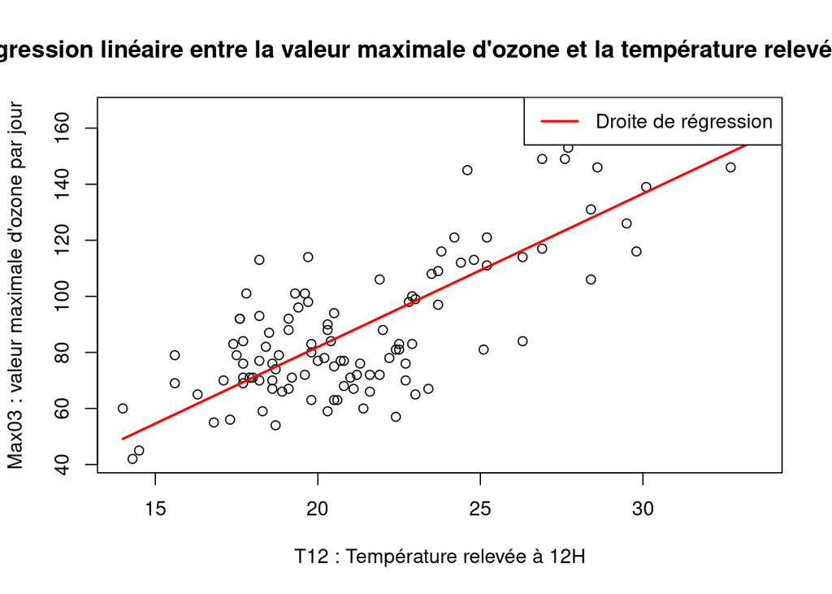

```r
# Attribution des variables réponse et explicatives
Y = ozone$maxO3
X = ozone$T12

#Calcul des moyennes empiriques
X_bar = mean(X)
Y_bar = mean(Y)

#Calcul de beta1 et beta0
beta1_manuel <- sum((X - X_bar) * (Y - Y_bar)) / sum((X - X_bar)^2)
beta0_manuel <- Y_bar - beta1_manuel * X_bar

#Calcul du modèle de régression linéaire
y = beta0_manuel + beta1_manuel*X
plot(X, Y, main = "Régression linéaire entre la valeur maximale d'ozone et la température relevée à 12H", ylab = "Max03 : valeur maximale d'ozone par jour", xlab = "T12 : Température relevée à 12H")
lines(X, y, col = 'red', lwd = 2)
legend("topright", legend = "Droite de régression", col = "red", lwd = 2)
```

### Question 2

En utilisant $lm$

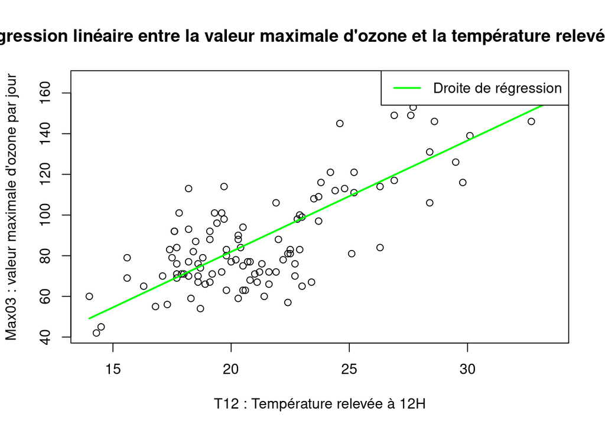

```r
#Calcul de la régression linéaire à l'aide de la commande lm
prediction = lm(Y ~ X, data = ozone)

#On récupère les coefficients beta0 et beta1 contenus dans la liste que génère la commande lm
beta0_lm = coef(prediction)[1]
beta1_lm = coef(prediction)[2]

#Calcul du modèle de régression linéaire avec les coefficients obtenus avec lm
y_lm = beta0_lm + beta1_lm*X
plot(X, Y, main = "Régression linéaire entre la valeur maximale d'ozone et la température relevée à 12H", ylab = "Max03 : valeur maximale d'ozone par jour", xlab = "T12 : Température relevée à 12H")
lines(X, y_lm, col = 'green', lwd = 2)
legend("topright", legend = "Droite de régression", col = "green", lwd = 2)
```

On obtient bien en effet les mêmes résultats en utilisant lm

### Question 3

Pour évaluer la qualité du modèle, on utilise la formule du cours qui permet de calculer $R^2$
$$R^2 =
\frac{||\hat{Y}-\overline{Y}_n||^2}{||Y-\overline{Y}_n||^2} =
\frac{\sum(\hat{Y}_i-\overline{Y}_n)^2}{\sum(Y_i-\overline{Y}_n)^2}$$

```r
# Calcul des estimateurs
beta_1barre = sum((X - X_bar) * (Y - Y_bar)) / sum((X - X_bar)^2)
beta_0barre = Y_bar - beta_1barre*X_bar

#Calcul de \hat{Y}
hatY = beta_0barre + beta_1barre*X

#Calcul du numérateur et dénominateur
SSE = sum((hatY-Y_bar)^2)
SST = sum((Y-Y_bar)^2)

#Calcul de R2
R2_manuel = SSE/SST
cat("R2 : ", R2_manuel)
```

```
## R2 :  0.6150674
```

### Avec lm

```r
prediction = lm(Y~X, data = ozone)
R2_lm = summary.lm(prediction)$r.squared
cat("R2 : ", R2_lm)
```

```
## R2 :  0.6150674
```

## Question 4

On souhaite calculer les bornes inferieurs et supérieurs de l’intervalle de confiance. On utilise la formule vue en cours
$$\beta_0 +\beta_1X_{n+1} \in \bigg[\hat{\beta}_0 +
\hat{\beta}_1 \pm t_{1-\frac{\alpha}{2};n-2}\cdot \hat\sigma_n\sqrt{1 +
\frac{1}{n}+
\frac{(x_{n+1}-\overline{x}_n)^2}{\sum(x_i-\overline{x}_n)^2}}\bigg]$$

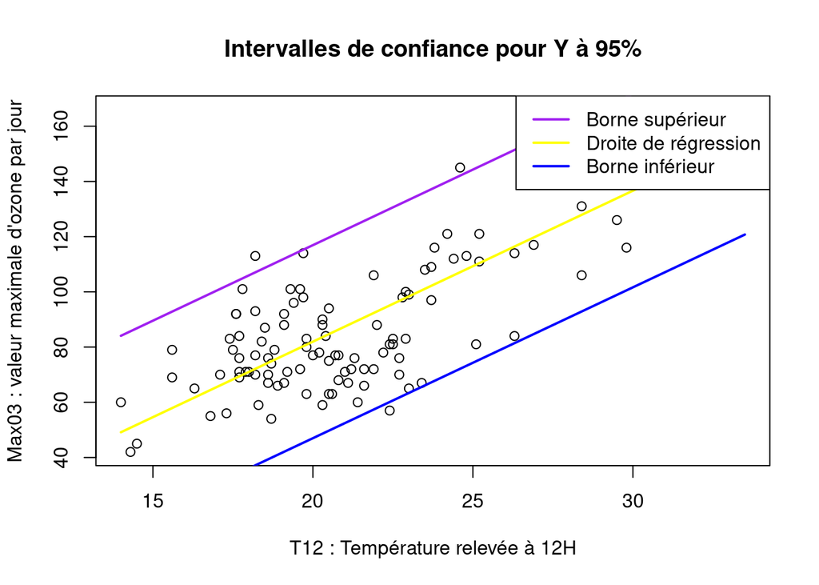

```r
n = length(Y)
# On définit alpha = 0.05 pour avoir un intervalle de confiance à 95%
alpha = 0.05

#Fonction qt pour le quantile d'une loi de Student a n-2 degrés de liberté
t = qt(1-alpha/2, n-2)

#Calcul du \hat{\sigma}
hat_sigma = sqrt(sum((Y-beta0_manuel - beta1_manuel*X)^2)/(n-2))

#Calcul de l'intervalle de confiance
interv = t*hat_sigma *sqrt(1 + (1/n) + (X-mean(X))/(sum((X-mean(X))^2)))
borneInf = beta_0barre + beta_1barre*X - interv
borneSup = beta_0barre + beta_1barre*X + interv

#Représentation graphique
plot(X,Y, main = "Intervalles de confiance pour Y à 95%", ylab = "Max03 : valeur maximale d'ozone par jour", xlab = "T12 : Température relevée à 12H")
lines(X, y_lm, col = 'yellow', lwd = 2)
curve(beta_0barre + beta_1barre*x - t*hat_sigma*sqrt(1 + (1/n) + (x-mean(X))/(sum((x-mean(X))^2))), from=min(X), to=max(X), col="blue", add=TRUE, lwd = 2)
curve(beta_0barre + beta_1barre*x + t*hat_sigma*sqrt(1 + (1/n) + (x-mean(X))/(sum((x-mean(X))^2))), from=min(X), to=max(X), col="purple", add=TRUE, lwd = 2)
legend("topright", legend = c("Borne supérieur","Droite de régression", "Borne inférieur"), col = c("purple", "yellow", "blue"), lwd = 2)
```

```r
prediction = lm(Y~X, data = ozone)
summary(prediction)
```

```
##
## Call:
## lm(formula = Y ~ X, data = ozone)
##
## Residuals:
##     Min      1Q  Median      3Q     Max
## -38.079 -12.735   0.257  11.003  44.671
##
## Coefficients:
##             Estimate Std. Error t value Pr(>|t|)
## (Intercept) -27.4196     9.0335  -3.035    0.003 **
## X             5.4687     0.4125  13.258   <2e-16 ***
## ---
## Signif. codes:  0 '***' 0.001 '**' 0.01 '*' 0.05 '.' 0.1 ' ' 1
##
## Residual standard error: 17.57 on 110 degrees of freedom
## Multiple R-squared:  0.6151, Adjusted R-squared:  0.6116
## F-statistic: 175.8 on 1 and 110 DF,  p-value: < 2.2e-16
```

## Question 6

Hypothèse de bruit gaussien.
$$Y_i =
\beta_0 + \beta_1X_i + \varepsilon_i$$
$$\hat{\varepsilon}_i= Y_i - \hat{Y}_i$$

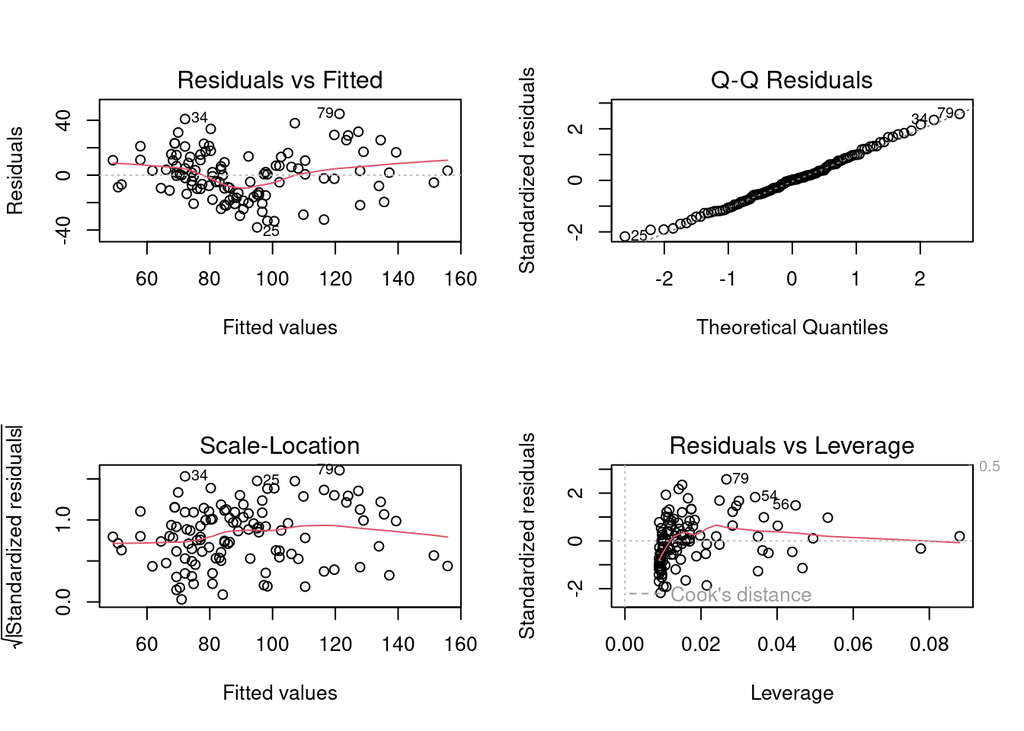

```r
par(mfrow = c(2,2))
plot(prediction)
```

```r
shapiro.test(prediction$residuals)
```

```
##
##  Shapiro-Wilk normality test
##
## data:  prediction$residuals
## W = 0.99235, p-value = 0.792
```

Le test de Shapiro-Wilk permet de vérifier si les résidus suivent une loi normale. Ici, on obtient $W = 0.99235$ et $p-value = 0.792$. Le fait que $W$ soit proche de $1$ signifie que les résidus ne présentent pas de déviation par rapport à la normalité. La valeur de $p-value$ étant bien au dessus de $0.05$ le seuil usuel, on en conclut qu’il n’y a pas assez de preuves pour rejeter la normalité des résidus. En conclusion, ce test permet de dire que les résidus semblent suivre une loi normale

## Exercice 2

```r
rm(list=ls())
```

On considère à présent les données contenues dans data1.RData. On souhaite étudier la dépendance de la consommation électrique (kwh) avec des variables décrivant la température (cldd et htdd). ## Question 1

```r
load("data1.RData")
data = khct.df
```

## Question 2

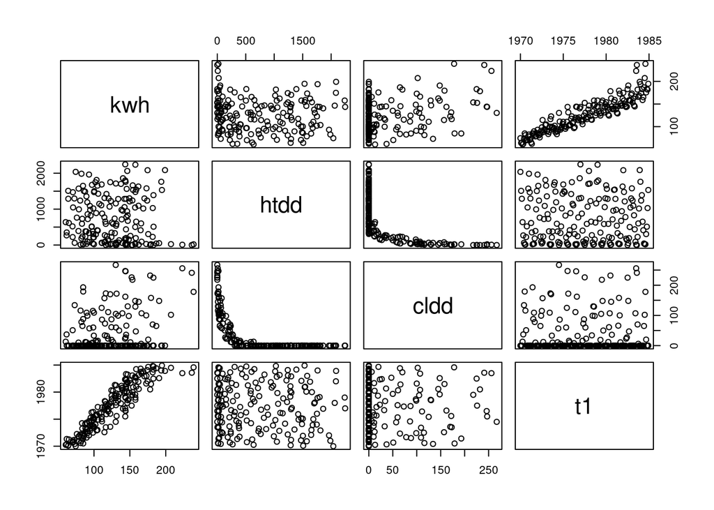

```r
pairs(data)
```

## Question 3

D’accord.

## Question 4

Régression linéaire à l’aide de la fonction $lm$ en considérant jusqu’a 1983.

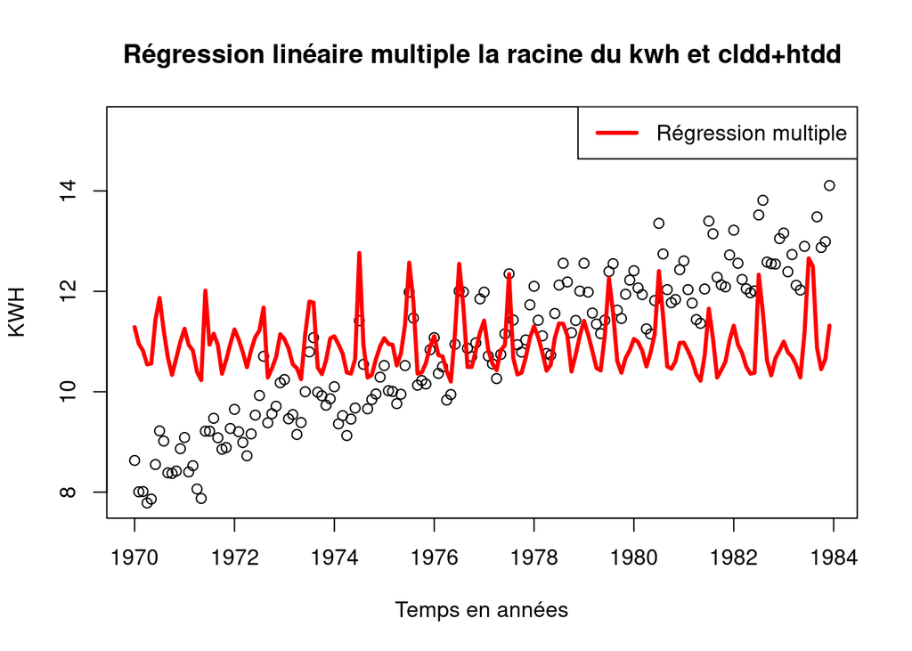

```r
data = data[1:168,]
Y = sqrt(data$kwh)
X1 = data$htdd
X2 = data$cldd
prediction = lm(Y ~ X1 + X2, data = data)

#On récupère les coefficients beta0 et beta1 contenus dans la liste que génère la commande lm
beta0_lm = coef(prediction)[1]
beta1_lm = coef(prediction)[2]
beta2_lm = coef(prediction)[3]

#Calcul du modèle de régression linéaire avec les coefficients obtenus avec lm
y_lm = beta0_lm + beta1_lm*X1 + beta2_lm*X2

plot(data$t1, Y, main = "Régression linéaire multiple la racine du kwh et cldd+htdd", ylab = "KWH", xlab = "Temps en années")
lines(data$t1, y_lm, col = 'red', lwd = 3)
legend("topright", legend = "Régression multiple", col = "red", lwd = 3)
```

## Question 5 Le modèle ne semble pas correspondre, les hypothèses de bruit ne sont pas satisfaites.

## Question 6

On considère le nouveau modèle liant $\sqrt{kwh}$, $htdd$, $cldd$, $t1$ et $t2=(t1-1977)^2$.

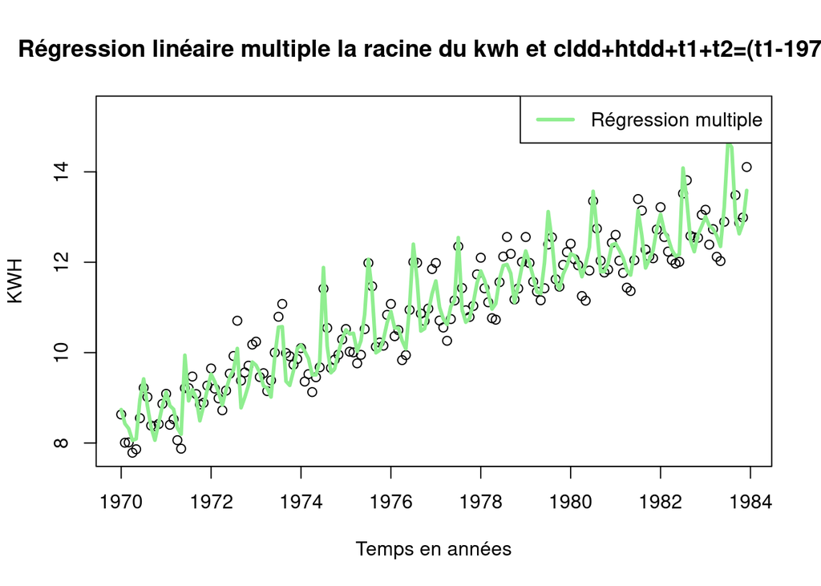

```r
data = data[1:168,]
Y = sqrt(data$kwh)
X1 = data$htdd
X2 = data$cldd
X3 = data$t1
X4 = (data$t1-1977)^2

prediction = lm(Y ~ X1 + X2 + X3 + X4, data = data)

#On récupère les coefficients beta0 et beta1 contenus dans la liste que génère la commande lm
beta0_lm = coef(prediction)[1]
beta1_lm = coef(prediction)[2]
beta2_lm = coef(prediction)[3]
beta3_lm = coef(prediction)[4]
beta4_lm = coef(prediction)[5]

#Calcul du modèle de régression linéaire avec les coefficients obtenus avec lm
y_lm = beta0_lm + beta1_lm*X1 + beta2_lm*X2 + beta3_lm*X3 + beta4_lm*X4
plot(data$t1, Y, main = "Régression linéaire multiple la racine du kwh et cldd+htdd+t1+t2=(t1-1977)²", xlab = "Temps en années", ylab = "KWH")
lines(data$t1, y_lm, col = 'lightgreen', lwd = 3)
legend("topright", legend = "Régression multiple", col = "lightgreen", lwd = 3)
```

## Question 7

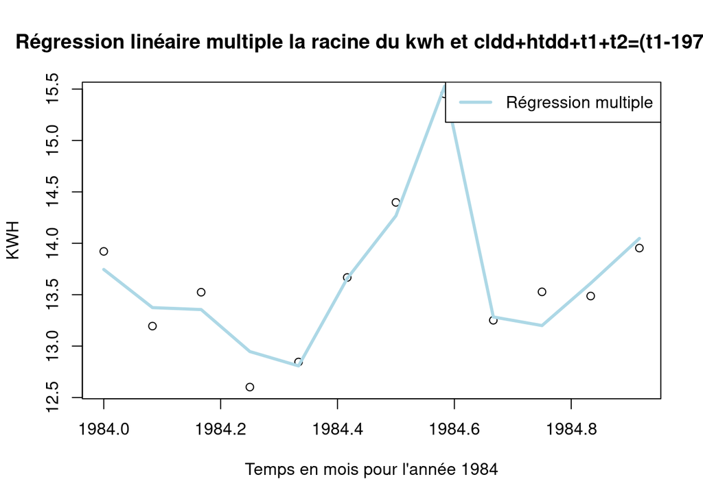

```r
rm(list=ls())
load("data1.RData")
data = khct.df
data = data[169:180,]

Y = sqrt(data$kwh)
X1 = data$htdd
X2 = data$cldd
X3 = data$t1
X4 = (data$t1-1977)^2

prediction = lm(Y ~ X1 + X2 + X3 + X4, data = data)

#On récupère les coefficients beta0 et beta1 contenus dans la liste que génère la commande lm
beta0_lm = coef(prediction)[1]
beta1_lm = coef(prediction)[2]
beta2_lm = coef(prediction)[3]
beta3_lm = coef(prediction)[4]
beta4_lm = coef(prediction)[5]

#Calcul du modèle de régression linéaire avec les coefficients obtenus avec lm
y_lm = beta0_lm + beta1_lm*X1 + beta2_lm*X2 + beta3_lm*X3 + beta4_lm*X4
plot(data$t1, Y, main = "Régression linéaire multiple la racine du kwh et cldd+htdd+t1+t2=(t1-1977)²", xlab = "Temps en mois pour l'année 1984", ylab = "KWH")
lines(data$t1, y_lm, col = 'lightblue', lwd = 3)
legend("topright", legend = "Régression multiple", col = "lightblue", lwd = 3)
```

Hypothèse de normalité du bruit :
$$\varepsilon \sim
\mathcal{N}(0,\sigma^2I\alpha)$$
$$\hat\varepsilon_{n+1}\sim\mathcal{N}(0,\overbrace{\sigma^2(X_{n+1}(\mathbb{X}^t\mathbb{X})^{-1}X_{n+1}+1}^{m^2}))$$
$$V(\hat\varepsilon_{n+1}) =
V(X_{n+1}(\beta-\hat\beta)) +
\underbrace{V(\varepsilon_{n+1})}_{\sigma^2}$$
$$\varepsilon_{n+1}\perp \!\!\! \perp
\beta$$
Intervalle de confiance : On cherche $r$ tel que
$$P(Y_{n+1} \in [\hat Y_{n+1}\pm r]) =
1-\alpha$$
$$P\bigg(\frac{X_{n+1} -
\hat Y_{n+1}}{\sigma m} \in \bigg[\pm \frac{r}{\sigma m}\bigg]\bigg) = 1
- \alpha$$
$$P\bigg(\frac{|\hat\varepsilon_{n+1}|}{\hat\sigma_n m} \leq
t_{n-rk(\mathbb{X})}(1-\frac{\alpha}{2})\bigg) = 1 - \alpha$$
Intervalle de confiance à $100(1-\alpha)\%$ :
$$X_{n+1} \in \bigg[ \hat Y_{n+1}\pm
\hat\sigma_n\cdot t_{n-rk(\mathbb{X})}(1-\frac{\alpha}{2})\sqrt{1 +
X_{n+1}(\mathbb{X}^t\mathbb{X})^{-1}X_{n+1}}\bigg]$$
où $n-rk(\mathbb{X})$ est le nombre de degrés de liberté de la loi de Student. $X_k = (1, X_k^{(1)}, ..., X_k^{(p)})$. Ici, $p=4$, $X^{(3)} = t_1$. On va chercher à tracer $Y_k$ en fonction de $t_1$ et de même pour $\hat Y_k$.

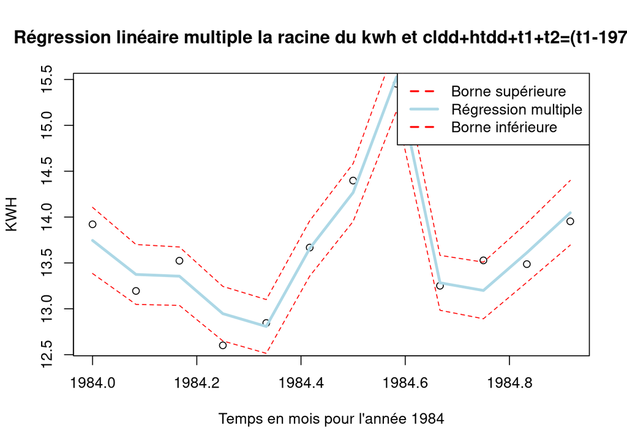

```r
# Nombre d'observations
n = length(Y)

# On définit alpha = 0.2 pour avoir un intervalle de confiance à 80%
alpha = 0.2

# Degré de liberté
d = n - length(coef(prediction))

# Quantile de la distribution t
t = qt(1 - alpha / 2, d)

# \hat{\sigma}
hat_sigma = sqrt(sum((Y - y_lm)^2) / (n - 2))

# Calcul des intervalles de confiance
interv = t * hat_sigma * sqrt(1 +
              (1/n) +
              ((X1 - mean(X1))^2 / sum((X1 - mean(X1))^2)) +
              ((X2 - mean(X2))^2 / sum((X2 - mean(X2))^2)) +
              ((X3 - mean(X3))^2 / sum((X3 - mean(X3))^2)) +
              ((X4 - mean(X4))^2 / sum((X4 - mean(X4))^2)))

borneInf = y_lm - interv
borneSup = y_lm + interv

# Tracé du graphique avec l'intervalle de confiance
plot(data$t1, Y, main = "Régression linéaire multiple la racine du kwh et cldd+htdd+t1+t2=(t1-1977)²", xlab = "Temps en mois pour l'année 1984", ylab = "KWH")
lines(data$t1, y_lm, col = 'lightblue', lwd = 3)
lines(data$t1, borneSup, col = 'red', lty = 2)
lines(data$t1, borneInf, col = 'red', lty = 2)
legend("topright", legend = c("Borne supérieure","Régression multiple", "Borne inférieure"), col = c("red", "lightblue", "red"), lwd = c(2, 3, 2), lty = c(2, 1, 2))
```